# Group4_Project1_Summer624

Devin Teran

6/21/2021

## Getting Data

First we will read the data into a dataframe from the xls.

```r
data <- read.xlsx2("/Users/devinteran/MSinDS/DATA624/DATA624/Project1/Data Set for Class.xls",sheetIndex = 1,colClasses = c('integer','character','double','double','double','double','double'),stringsAsFactors=FALSE)
```

## Exploratory Data Analysis

**SeriesInd** - this provides the time element in our data. It represents a frequency of 1.  
**group** - this will be what we are forecasted/our output prediction.  
**Var01, Var02, Var03, Var05, Var07** - these are to be used in different combinations in order to forecast 140 series data within each group

```r
data[1:15,] %>%
  kbl() %>%
  kable_minimal()
```

| SeriesInd | group | Var01 | Var02 | Var03 | Var05 | Var07 |
| --- | --- | --- | --- | --- | --- | --- |
| 40669 | S03 | 30.64286 | 123432400 | 30.34000 | 30.49000 | 30.57286 |
| 40669 | S02 | 10.28000 | 60855800 | 10.05000 | 10.17000 | 10.28000 |
| 40669 | S01 | 26.61000 | 10369300 | 25.89000 | 26.20000 | 26.01000 |
| 40669 | S06 | 27.48000 | 39335700 | 26.82000 | 27.02000 | 27.32000 |
| 40669 | S05 | 69.26000 | 27809100 | 68.19000 | 68.72000 | 69.15000 |
| 40669 | S04 | 17.20000 | 16587400 | 16.88000 | 16.94000 | 17.10000 |
| 40670 | S03 | 30.79857 | 150476200 | 30.46428 | 30.65714 | 30.62571 |
| 40670 | S02 | 11.24000 | 215620200 | 10.40000 | 10.45000 | 10.96000 |
| 40670 | S01 | 26.30000 | 10943800 | 25.70000 | 25.95000 | 25.86000 |
| 40670 | S06 | 28.24000 | 55416000 | 27.24000 | 27.27000 | 28.07000 |
| 40670 | S05 | 69.45000 | 30174700 | 68.80000 | 69.19000 | 69.42000 |
| 40670 | S04 | 17.23000 | 11718100 | 17.00000 | 17.22000 | 17.23000 |
| 40671 | S03 | 30.74714 | 138040000 | 30.10714 | 30.62571 | 30.13857 |
| 40671 | S02 | 11.46000 | 200070600 | 11.13000 | 11.21000 | 11.37000 |
| 40671 | S01 | 26.03000 | 8933800 | 25.56000 | 25.90000 | 25.67000 |

## Cleaning Data

```r
S01 <- data %>%
  mutate(date = as.Date(SeriesInd, origin = '1898-08-30')) %>%
  filter(SeriesInd < 43022 & group == 'S01') %>%
  select (SeriesInd,date,Var01,Var02)
```

```r
S01[1:15,] %>%
  kbl() %>%
  kable_minimal()
```

| SeriesInd | date | Var01 | Var02 |
| --- | --- | --- | --- |
| 40669 | 2010-01-04 | 26.61 | 10369300 |
| 40670 | 2010-01-05 | 26.30 | 10943800 |
| 40671 | 2010-01-06 | 26.03 | 8933800 |
| 40672 | 2010-01-07 | 25.84 | 10775400 |
| 40673 | 2010-01-08 | 26.34 | 12875600 |
| 40676 | 2010-01-11 | 26.49 | 11677000 |
| 40677 | 2010-01-12 | 26.03 | 21165300 |
| 40678 | 2010-01-13 | 25.16 | 18809200 |
| 40679 | 2010-01-14 | 25.00 | 22908400 |
| 40680 | 2010-01-15 | 24.77 | 20359100 |
| 40684 | 2010-01-19 | 24.78 | 11783800 |
| 40685 | 2010-01-20 | 24.61 | 13253500 |
| 40686 | 2010-01-21 | 24.88 | 18407800 |
| 40687 | 2010-01-22 | 24.17 | 21806400 |
| 40690 | 2010-01-25 | 23.82 | 20192100 |

## Missing Data

There are 2 rows within the group S01 that is missing a **Var01** value.

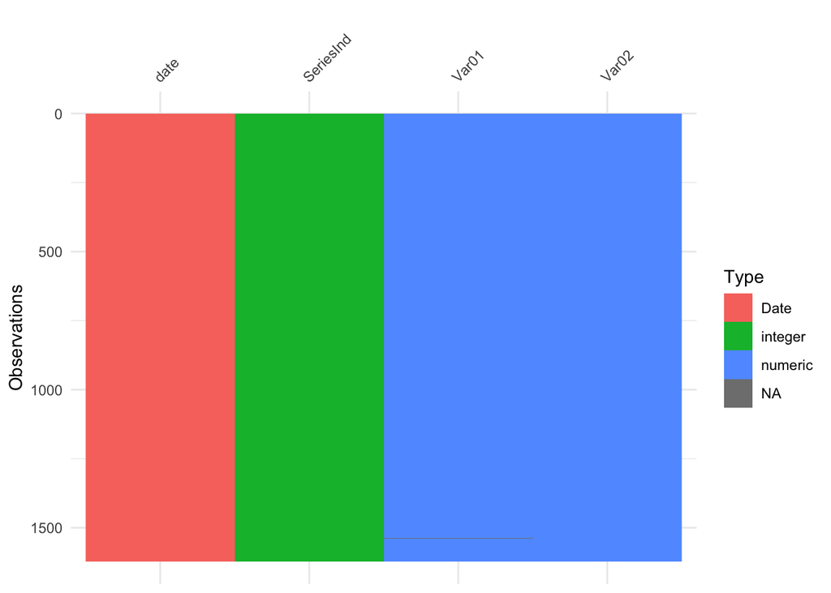

```r
library(visdat)
vis_dat(S01)
```

```r
S01[is.na(S01$Var01)|is.na(S01$Var02),]
```

|  | SeriesInd | date | Var01 | Var02 |
| --- | --- | --- | --- | --- |
| 1537 | 42897 | 2016-02-10 | NA | 7329600 |
| 1538 | 42898 | 2016-02-11 | NA | 6121400 |

```r
prev_value <- S01[c(1536),'Var01']
S01_clean <- S01
S01_clean[is.na(S01_clean$Var01)|is.na(S01_clean$Var02),]$Var01 <- prev_value
```

## Visualize Data

```r
require(scales)
```

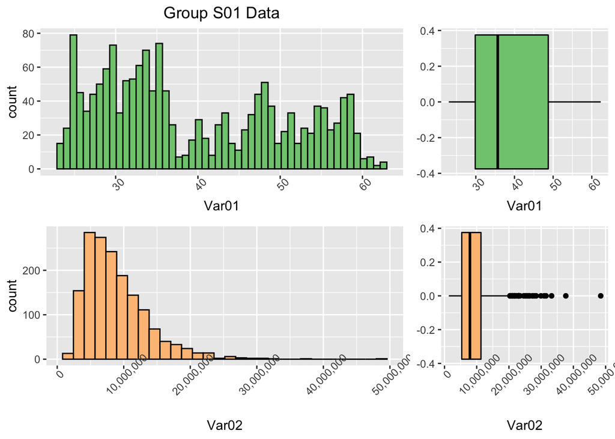

```r
S01_Var01 <- ggplot(S01_clean, aes(x=Var01)) +
  geom_histogram(bins=50,color='black',fill="#7fc97f") +
  ggtitle("Group S01 Data") +
  theme(plot.title = element_text(hjust = 0.5)) +
  theme(axis.text.x = element_text(angle = 45))
S01_Var01_boxplot <- ggplot(S01_clean, aes(x=Var01)) +
  geom_boxplot(color='black',fill="#7fc97f") +
  ggtitle("") +
  theme(plot.title = element_text(hjust = 0.5)) +
  theme(axis.text.x = element_text(angle = 45))
S01_Var02 <- ggplot(S01_clean, aes(x=Var02)) +
  geom_histogram(bins=30,color='black',fill='#fdc086') +
  scale_x_continuous(labels = comma) +
  theme(axis.text.x = element_text(angle = 45))
S01_Var02_boxplot <- ggplot(S01_clean, aes(x=Var02)) +
  geom_boxplot(color='black',fill="#fdc086") +
  theme(plot.title = element_text(hjust = 0.5)) +
  scale_x_continuous(labels = comma) +
  theme(axis.text.x = element_text(angle = 45))
grid.arrange(S01_Var01,S01_Var01_boxplot,S01_Var02,S01_Var02_boxplot,nrow=2,widths=2:1)
```

- Variable 1 data has multiple peaks
- Variable 02 is right skewed with many outliers

## Decomposition - Trend, Seasonal, Error

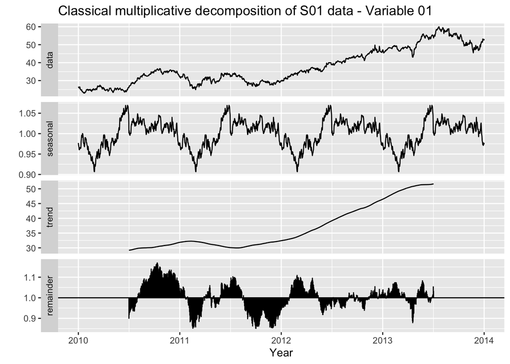

```r
t <- ts(S01$Var01, start = 2010, end = 2014, frequency = 365)
t %>% decompose(type="multiplicative") %>%
  autoplot() + xlab("Year") +
  ggtitle("Classical multiplicative decomposition of S01 data - Variable 01")
```

- There appears to be an increasing trend and clear seasonality

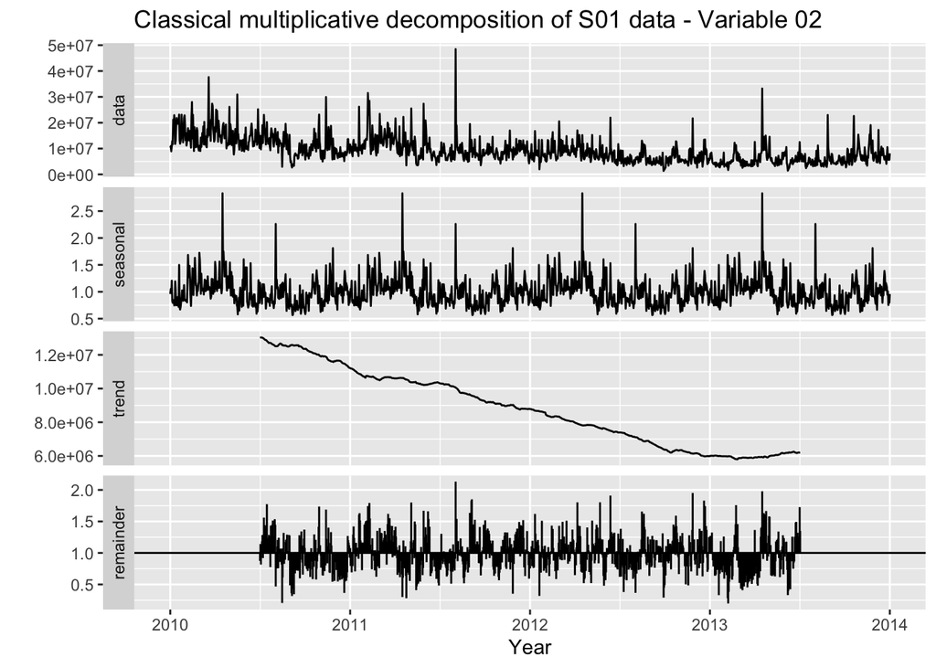

```r
t <- ts(S01$Var02, start = 2010, end = 2014, frequency = 365)
t %>% decompose(type="multiplicative") %>%
  autoplot() + xlab("Year") +
  ggtitle("Classical multiplicative decomposition of S01 data - Variable 02")
```

- There appears to be an decreasing trend and pontential seasonality

## Time, ACF and PACF Plots

### Variable 01

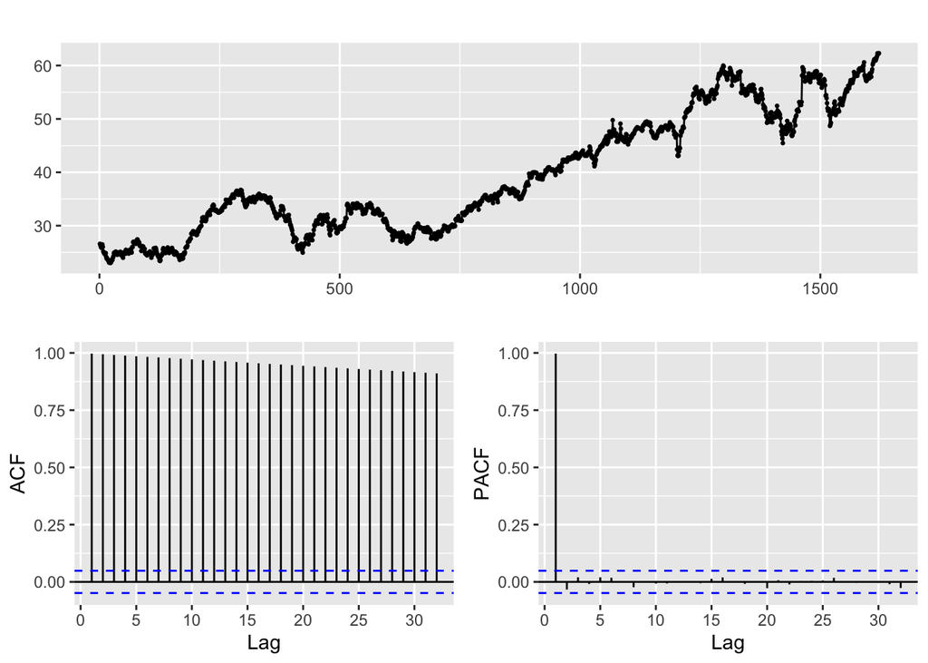

```r
ggtsdisplay(S01_clean$Var01)
```

- Variable 01 data has a clear trend and is non-stationary data
- The ACF plot shows an initial large autocorrelation value that gradually decreases as the lag increases, which indicates a trend
- The PACF shows a single significant value for lag 1. This means the first lag explains all of the correlation that exists in the higher lags. This implies a consistent trend

### Differencing Variable 01 Data

#### Trend

```r
S01_clean$Var01 %>% ur.kpss() %>% summary()
```

```
##
## #######################
## # KPSS Unit Root Test #
## #######################
##
## Test is of type: mu with 8 lags.
##
## Value of test-statistic is: 16.0591
##
## Critical value for a significance level of:
##                 10pct  5pct 2.5pct  1pct
## critical values 0.347 0.463  0.574 0.739
```

Here we see a test statistic of 16.0591 which is above 0.463 so we know we can reject the original statement that the *Variable 01 data is stationary*.

From our KPSS test we confirmed that Variable 01 data is non-stationary and we need to differentiate it in an attempt to make it stationary. Here we are differentiating the data and running the KPSS test again. We see that our test-statistic is much lower and we can accept the assumption that *Variable 01 data after being differentiated once is now stationary*.

```r
Var01_diff <- c(0,S01_clean$Var01 %>% diff())
S01_clean$Var01_diff <- Var01_diff

S01_clean$Var01_diff %>% ur.kpss() %>% summary()
```

```
##
## #######################
## # KPSS Unit Root Test #
## #######################
##
## Test is of type: mu with 8 lags.
##
## Value of test-statistic is: 0.1003
##
## Critical value for a significance level of:
##                 10pct  5pct 2.5pct  1pct
## critical values 0.347 0.463  0.574 0.739
```

#### Seasonal

To check for whether seasonal differencing is necessary we will run the function, **nsdiffs()**. If there is seasonality in the data, the value returned will be greater than 0.64. If it is less than 0.64, there is no seasonality.

```r
t <- ts(S01_clean$Var01,frequency=365)
nsdiffs(t)
```

```
## [1] 0
```

No seasonal differencing is needed since the value is equal to 0. This is interesting since visually it looked like there was seasonality in our decomposed plot seen above.

### Variable 02

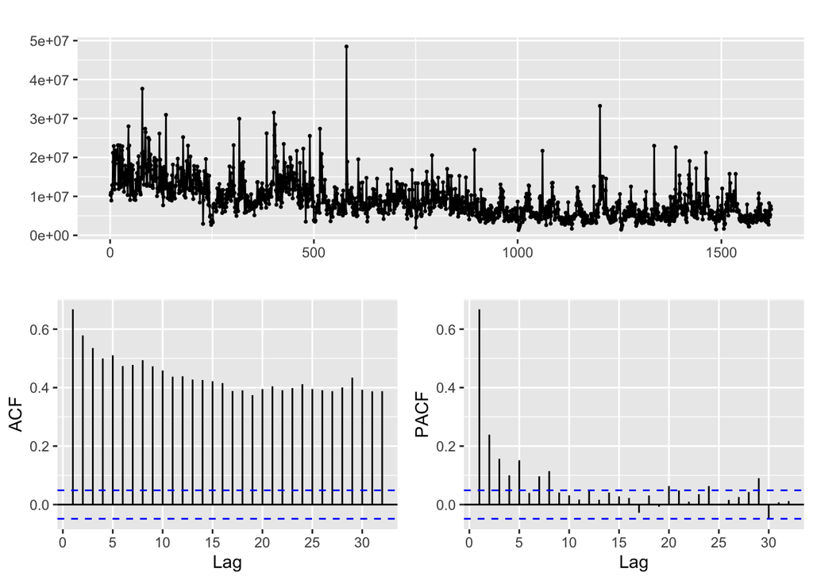

```r
ggtsdisplay(S01_clean$Var02)
```

- Variable 02 data is a little less clear but appears to have a negative trend and is non-stationary data
- The ACF plot shows an initial large autocorrelation value that gradually decreases as the lag increases, which indicates a trend
- The PACF shows a significant value for lag 1. There also appears to be some seasonality since autocorrelations increase slightly as the lag increases.

### Differencing Variable 02 Data

#### Trend

Just like we did with Variable 01, we are running the KPSS test and looking to reject the statement *Variable 02 is stationary*. To do this the KPSS test-statistic must be larger than 0.463, which it is. We reject the statement that Variable 02 data is stationary, which matches our previous theory.

```r
S01_clean$Var02 %>% ur.kpss() %>% summary()
```

```
##
## #######################
## # KPSS Unit Root Test #
## #######################
##
## Test is of type: mu with 8 lags.
##
## Value of test-statistic is: 10.3302
##
## Critical value for a significance level of:
##                 10pct  5pct 2.5pct  1pct
## critical values 0.347 0.463  0.574 0.739
```

The KPSS test helped us confirm that Variable 02 data is non-stationary and we need to differentiate it as well. Here we are differentiating the data and running the KPSS test again. We see that our test-statistic is much lower and we can accept the assumption that *Variable 02 data after being differentiated once is now stationary*.

```r
Var02_diff <- c(0,S01_clean$Var02 %>% diff())
S01_clean$Var02_diff <- Var02_diff

S01_clean$Var02_diff %>% ur.kpss() %>% summary()
```

```
##
## #######################
## # KPSS Unit Root Test #
## #######################
##
## Test is of type: mu with 8 lags.
##
## Value of test-statistic is: 0.0042
##
## Critical value for a significance level of:
##                 10pct  5pct 2.5pct  1pct
## critical values 0.347 0.463  0.574 0.739
```

#### Seasonal

To check for whether seasonal differencing is necessary we will run the function, **nsdiffs()**. If there is seasonality in the data, the value returned will be greater than 0.64. If it is less than 0.64, there is no seasonality.

```r
t <- ts(S01_clean$Var02,frequency=365)
nsdiffs(t)
```

```
## [1] 0
```

No seasonal differencing is needed since the value is equal to 0.

## Splitting Data into Test & Training

Here we will use 80% of our data as training data and will reserve 20% of our data for testing.

```r
break_num <- floor(nrow(S01_clean)*0.8)
train <- S01_clean[1:break_num,]
test  <- S01_clean[(break_num+1):nrow(S01_clean),]
```

## Time Series Plots

### Auto Arima - Variable 01

The first model we will test for Variable 01 is the **auto.arima** model with 1 difference.

```r
S01_train_Var01 <- ts(select(train,Var01))

fit_var01_auto <- auto.arima(S01_train_Var01,d=1)
summary(fit_var01_auto)
```

```
## Series: S01_train_Var01
## ARIMA(0,1,1) with drift
##
## Coefficients:
##          ma1   drift
##       0.0845  0.0254
## s.e.  0.0286  0.0130
##
## sigma^2 estimated as 0.1859:  log likelihood=-747.66
## AIC=1501.32   AICc=1501.34   BIC=1516.83
##
## Training set error measures:
##                        ME      RMSE       MAE         MPE      MAPE      MASE
## Training set 2.312112e-05 0.4306647 0.3040085 -0.01941244 0.8958063 0.9926807
##                      ACF1
## Training set -0.002772543
```

### ETS - Variable 01

Second we will use the exponential smoothing (ETS) model.

```r
fit_var01_ets <- ets(S01_train_Var01)
summary(fit_var01_ets)
```

```
## ETS(A,A,N)
##
## Call:
##  ets(y = S01_train_Var01)
##
##   Smoothing parameters:
##     alpha = 0.9999
##     beta  = 1e-04
##
##   Initial states:
##     l = 26.4127
##     b = 0.0254
##
##   sigma:  0.4328
##
##      AIC     AICc      BIC
## 7130.325 7130.371 7156.164
##
## Training set error measures:
##                        ME      RMSE       MAE         MPE      MAPE    MASE
## Training set 0.0007689551 0.4321495 0.3061459 -0.01885709 0.9020201 0.99966
##                    ACF1
## Training set 0.07834262
```

### Forecast on Test Data - Variable 01

```r
forecast_auto_var01 <- fit_var01_auto %>% forecast(nrow(train))
accuracy(forecast_auto_var01,S01_clean[1298:nrow(S01_clean),c('Var01')])
```

```
##                         ME      RMSE       MAE          MPE       MAPE
## Training set  2.312112e-05 0.4306647 0.3040085  -0.01941244  0.8958063
## Test set     -8.699160e+00 9.5792251 8.7037779 -16.35612988 16.3638362
##                    MASE         ACF1
## Training set  0.9926807 -0.002772543
## Test set     28.4204991           NA
```

```r
forecast_ets_var01 <- fit_var01_ets %>% forecast(nrow(train))
accuracy(forecast_ets_var01,S01_clean[1298:nrow(S01_clean),c('Var01')])
```

```
##                         ME      RMSE       MAE          MPE       MAPE     MASE
## Training set  0.0007689551 0.4321495 0.3061459  -0.01885709  0.9020201  0.99966
## Test set     -8.7295616713 9.6092604 8.7341364 -16.41130797 16.4189421 28.51963
##                    ACF1
## Training set 0.07834262
## Test set             NA
```

### Auto Arima - Variable 02

The first model we will test for Variable 02 is the **auto.arima** model with 1 difference.

```r
S01_train_Var02 <- ts(select(train,Var02))

fit_var02_auto <- auto.arima(S01_train_Var02,d=1)
summary(fit_var02_auto)
```

```
## Series: S01_train_Var02
## ARIMA(1,1,3)
##
## Coefficients:
##          ar1      ma1     ma2     ma3
##       0.8498  -1.4789  0.3779  0.1086
## s.e.  0.0587   0.0667  0.0537  0.0417
##
## sigma^2 estimated as 1.197e+13:  log likelihood=-21351.15
## AIC=42712.31   AICc=42712.35   BIC=42738.14
##
## Training set error measures:
##                     ME    RMSE     MAE       MPE     MAPE      MASE        ACF1
## Training set -128388.4 3452637 2293964 -12.30189 27.04777 0.8620093 0.003851951
```

Second we will use the exponential smoothing (ETS) model.

```r
fit_var02_ets <- ets(S01_train_Var02)
summary(fit_var02_ets)
```

```
## ETS(M,A,N)
##
## Call:
##  ets(y = S01_train_Var02)
##
##   Smoothing parameters:
##     alpha = 0.8174
##     beta  = 0.0011
##
##   Initial states:
##     l = 7092879.6943
##     b = 1533385.7915
##
##   sigma:  0.3611
##
##      AIC     AICc      BIC
## 48309.00 48309.04 48334.84
##
## Training set error measures:
##                     ME    RMSE     MAE       MPE     MAPE     MASE       ACF1
## Training set -901614.9 3993393 2691723 -17.35243 30.70294 1.011477 -0.2385468
```

### Forecast on Test Data - Variable 02

```r
forecast_auto_var02 <- fit_var02_auto %>% forecast(nrow(test))
accuracy(forecast_auto_var02,S01_clean[1298:nrow(S01_clean),c('Var02')])
```

```
##                     ME    RMSE     MAE       MPE     MAPE      MASE        ACF1
## Training set -128388.4 3452637 2293964 -12.30189 27.04777 0.8620093 0.003851951
## Test set      530138.9 3208081 2161143 -10.00262 34.96505 0.8120989          NA
```

```r
forecast_ets_var02 <- fit_var02_ets %>% forecast(nrow(test))
accuracy(forecast_ets_var02,S01_clean[1298:nrow(S01_clean),c('Var02')])
```

```
##                       ME     RMSE      MAE        MPE      MAPE      MASE
## Training set   -901614.9  3993393  2691723  -17.35243  30.70294  1.011477
## Test set     -44859673.6 51987522 44898015 -885.66149 885.82828 16.871455
##                    ACF1
## Training set -0.2385468
## Test set             NA
```

## Residuals of Models

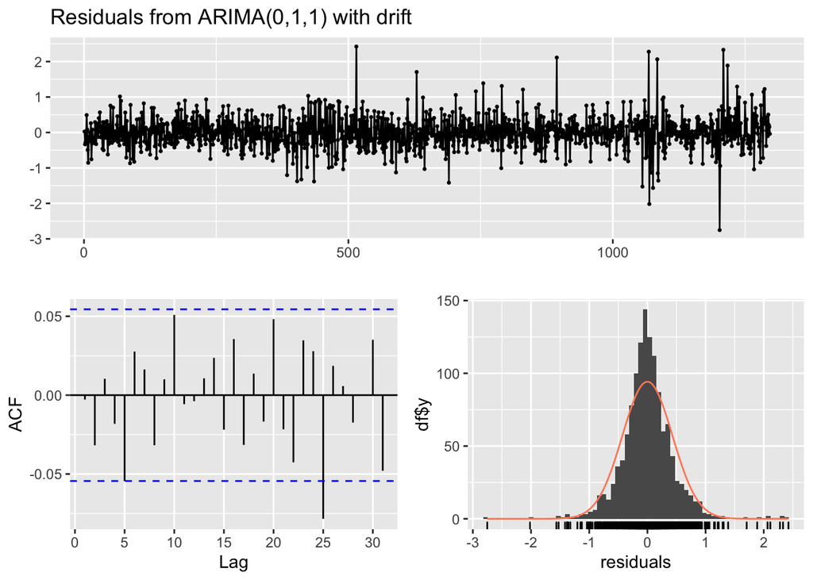

```
##
##  Ljung-Box test
##
## data:  Residuals from ARIMA(0,1,1) with drift
## Q* = 11.952, df = 8, p-value = 0.1534
##
## Model df: 2.   Total lags used: 10
```

```r
checkresiduals(fit_var01_auto)
```

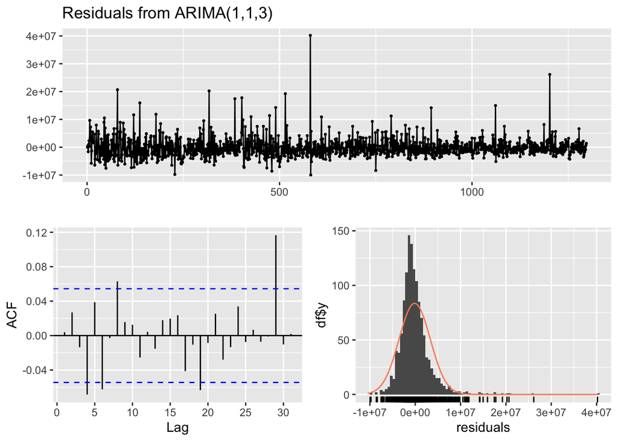

```
##
##  Ljung-Box test
##
## data:  Residuals from ARIMA(1,1,3)
## Q* = 20.061, df = 6, p-value = 0.002702
##
## Model df: 4.   Total lags used: 10
```

```r
checkresiduals(fit_var02_auto)
```

## Forecasting out 140 Variables

Both auto.arima modeling methods produced the best models with the lowest MAPE values. For Variable 01 the model that was produce was ARIMA(0,1,1) with drift for Variable 02 the model is ARIMA(1,1,3).

Now we will forecast out 140 periods using our selected models for Variable 01 and 02.

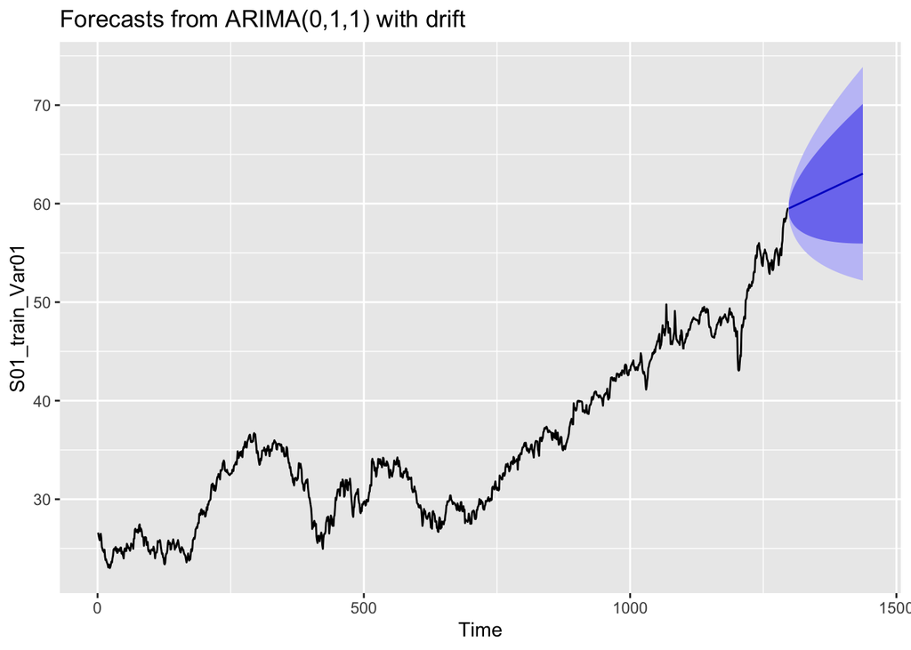

```r
final_forecast_auto_var01 <- fit_var01_auto %>% forecast(140)
autoplot(final_forecast_auto_var01)
```

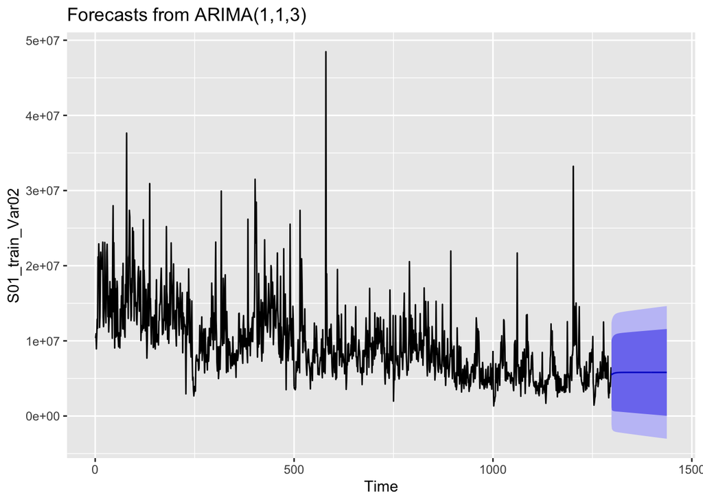

```r
final_forecast_auto_var02 <- fit_var02_auto %>% forecast(140)
autoplot(final_forecast_auto_var02)
```